# HW 4 - College Majors

Annie Hou

02/19/2024

## Load packages and data

```r
library(tidyverse)
library(scales)
library(fivethirtyeight)
```

## Exercises

### Exercise 1

The top-3 majors that have the highest percentage of women are: Early Childhood Education, Communication Disorders Sciences And Services, and Medical Assisting Services.

```r
college_recent_grads %>%
  arrange(desc(sharewomen)) %>%
  select(major, total, sharewomen) %>%
  top_n(3, sharewomen)
```

```
## # A tibble: 3 × 3
##   major                                         total sharewomen
##   <chr>                                         <int>      <dbl>
## 1 Early Childhood Education                     37589      0.969
## 2 Communication Disorders Sciences And Services 38279      0.968
## 3 Medical Assisting Services                    11123      0.928
```

### Exercise 2

We choose the median because it is less likely to be affected by outliers. For example, a few people may have extremely high incomes, which would increase the mean a lot; or a few people may also have extremely low incomes, leading to a large decrease in mean. However, the median only cares about the middle value of a series of data, which will not be largely affected by those extremes. Therefore, median could better indicate the typical income for a group.

### Exercise 3

I chose a binwidth of $1000, because it offers a more detailed view of the means. It could show more specific patterns in the data, which could be helpful for more in-depth analysis.

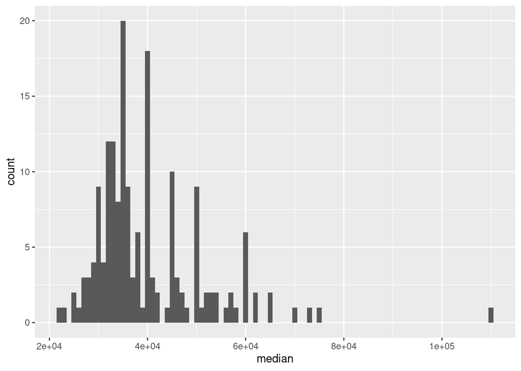

```r
ggplot(college_recent_grads, aes(x = median)) +
  geom_histogram(binwidth = 1000)
```

```r
college_recent_grads %>%
  summarize(min = min(median), max = max(median),
            mean = mean(median), med = median(median),
            sd = sd(median),
            q1 = quantile(median, probs = 0.25),
            q3 = quantile(median, probs = 0.75))
```

```
## # A tibble: 1 × 7
##     min    max   mean   med     sd    q1    q3
##   <dbl>  <dbl>  <dbl> <dbl>  <dbl> <dbl> <dbl>
## 1 22000 110000 40151. 36000 11470. 33000 45000
```

### Exercise 4

The center of the distribution is 36000, which is lower than the mean of 40151, which means the distribution of the incomes are clustered on the left side. It also means that while the majority majors have the median incomes that are clustered on the lower end, there are still some majors with significantly higher median incomes, like the plot shows, and that makes the mean larger than the median.

The spread of the data is 11470, measured by the standard deviation. It means the distribution of median incomes is relatively wide, which we can also oberserve from the graph. The interquartile range is from the first quartile at 33000 to the third quartile at 45000, which includes the middle 50% of the data, so half of the majors have median incomes within this range.

For the unusal observations, we can see from the graph that there are majors that have very high median incomes far on the right side. By the max value in the table, we know that it has reached 110000, which is far more than the median and mean. Such outlier could affect the mean and spread of the distribution.

### Exercise 5

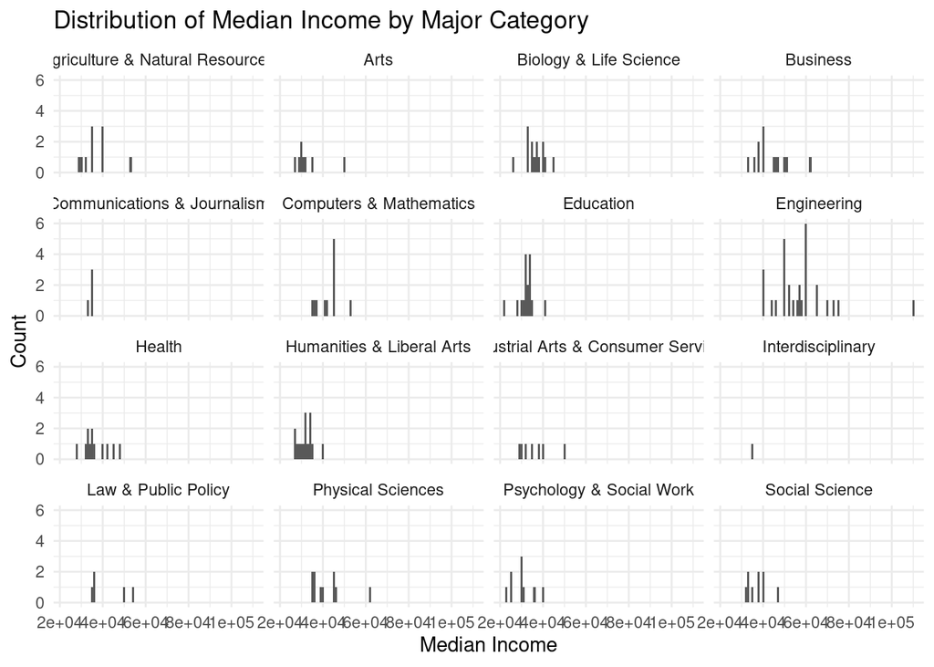

```r
ggplot(college_recent_grads, aes(x = median)) +
  geom_histogram(binwidth = 1000) +
  facet_wrap(~major_category) +
  theme_minimal() +
  labs(title = "Distribution of Median Income by Major Category",
       x = "Median Income",
       y = "Count")
```

### Exercise 6

```r
college_recent_grads %>%
  group_by(major_category) %>%
  summarize(median_income = median(median)) %>%
  arrange(desc(median_income))
```

```
## # A tibble: 16 × 2
##    major_category                      median_income
##    <chr>                                       <dbl>
##  1 Engineering                                 57000
##  2 Computers & Mathematics                     45000
##  3 Business                                    40000
##  4 Physical Sciences                           39500
##  5 Social Science                              38000
##  6 Biology & Life Science                      36300
##  7 Law & Public Policy                         36000
##  8 Agriculture & Natural Resources             35000
##  9 Communications & Journalism                 35000
## 10 Health                                      35000
## 11 Industrial Arts & Consumer Services         35000
## 12 Interdisciplinary                           35000
## 13 Education                                   32750
## 14 Humanities & Liberal Arts                   32000
## 15 Arts                                        30750
## 16 Psychology & Social Work                    30000
```

From the table, we can see that the top 3 majors with the highest typical median income are: engineering, computers & mathematics, and business.

### Exercise 7

```r
college_recent_grads %>%
  count(major_category) %>%
  arrange(n)
```

```
## # A tibble: 16 × 2
##    major_category                          n
##    <chr>                               <int>
##  1 Interdisciplinary                       1
##  2 Communications & Journalism             4
##  3 Law & Public Policy                     5
##  4 Industrial Arts & Consumer Services     7
##  5 Arts                                    8
##  6 Psychology & Social Work                9
##  7 Social Science                          9
##  8 Agriculture & Natural Resources        10
##  9 Physical Sciences                      10
## 10 Computers & Mathematics                11
## 11 Health                                 12
## 12 Business                               13
## 13 Biology & Life Science                 14
## 14 Humanities & Liberal Arts              15
## 15 Education                              16
## 16 Engineering                            29
```

From the table, we can see that the least 3 popular majors are: interdisciplinary, communications & journalism, law & public policy.

### Exercise 8

```r
stem_categories <- c("Biology & Life Science",
                     "Computers & Mathematics",
                     "Engineering",
                     "Physical Sciences")
college_recent_grads <- college_recent_grads %>%
  mutate(major_type = ifelse(major_category %in% stem_categories,
                             "stem", "not stem"))
college_recent_grads %>%
  filter(major_type == "stem", median < 36000)%>%
  select(major, median, p25th, p75th) %>%
  arrange(desc(median))
```

```
## # A tibble: 10 × 4
##    major                                 median p25th p75th
##    <chr>                                  <dbl> <dbl> <dbl>
##  1 Environmental Science                  35600 25000 40200
##  2 Multi-Disciplinary Or General Science  35000 24000 50000
##  3 Physiology                             35000 20000 50000
##  4 Communication Technologies             35000 25000 45000
##  5 Neuroscience                           35000 30000 44000
##  6 Atmospheric Sciences And Meteorology   35000 28000 50000
##  7 Miscellaneous Biology                  33500 23000 48000
##  8 Biology                                33400 24000 45000
##  9 Ecology                                33000 23000 42000
## 10 Zoology                                26000 20000 39000
```

### Exercise 9

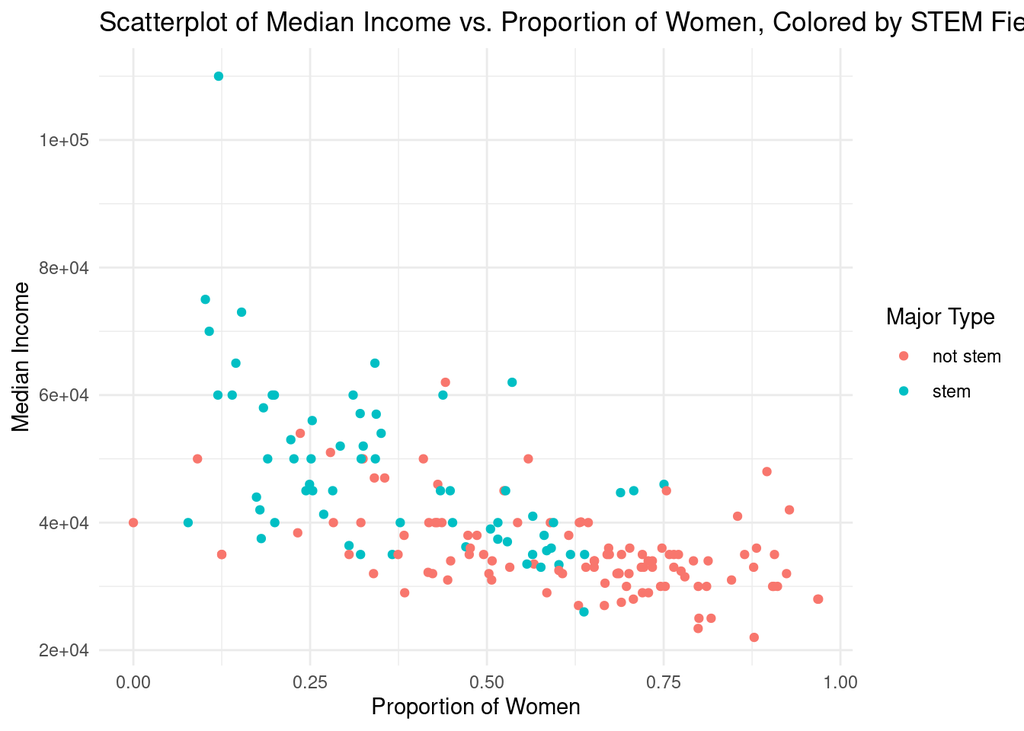

```r
ggplot(college_recent_grads, aes(x = sharewomen, y = median, color = major_type)) +
  geom_point() +
  labs(x = "Proportion of Women", y = "Median Income", color = "Major Type") +
  theme_minimal() +
  ggtitle("Scatterplot of Median Income vs. Proportion of Women, Colored by STEM Field")
```

The scatterplot first shows a negative correlation between the proportion of women and the median income of that major. Because when the proportion of women increases (to the right side of the x-axis), the median income tends to decrease. Also, there are less STEM majors as the proportion of women increases and the median income decreases, because non-STEM majors (red dots) are more clustered at the lower median income range and have a higher proportion of women (right bottom side of the plot). This may indicate that majors with more women may less likely to have high median income or being STEM.

### Exercise 10

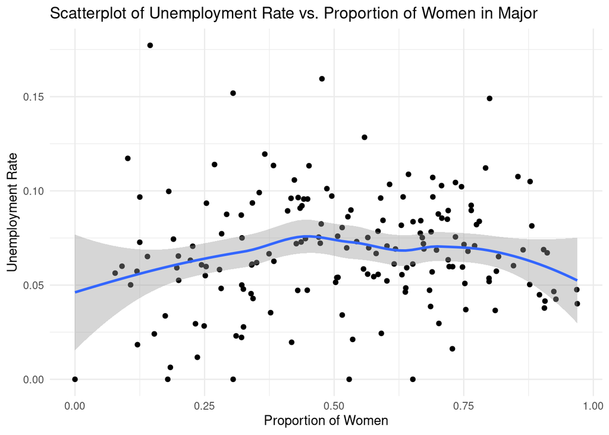

```r
ggplot(college_recent_grads, aes(x = sharewomen, y = unemployment_rate)) +
  geom_point() +
  geom_smooth() +
  labs(title = "Scatterplot of Unemployment Rate vs. Proportion of Women in Major",
       x = "Proportion of Women",
       y = "Unemployment Rate") +
  theme_minimal()
```